# DATA 599 - Survival Analysis HW4 - Charles Hanks

Due: February 17, 2023

DATASET: genfan (preloaded with survival package)

This dataset contains the failure time (hrs of service) of 70 diesel engine fans.

Please complete the following:

## A (20)

Fit a KM curve to the data. Make sure your graph has labels and a title.

```r
km.genfan = survfit(Surv(genfan$hours,genfan$status)~1)
summary(km.genfan)
```

```
## Call: survfit(formula = Surv(genfan$hours, genfan$status) ~ 1)
##
##  time n.risk n.event survival std.err lower 95% CI upper 95% CI
##   450     70       1    0.986  0.0142        0.958        1.000
##  1150     68       2    0.957  0.0244        0.910        1.000
##  1600     65       1    0.942  0.0282        0.888        0.999
##  2070     55       2    0.908  0.0361        0.840        0.981
##  2080     53       1    0.891  0.0392        0.817        0.971
##  3100     47       1    0.872  0.0427        0.792        0.960
##  3450     45       1    0.852  0.0460        0.767        0.947
##  4600     34       1    0.827  0.0510        0.733        0.933
##  6100     26       1    0.795  0.0581        0.689        0.918
##  8750      9       1    0.707  0.0980        0.539        0.928
```

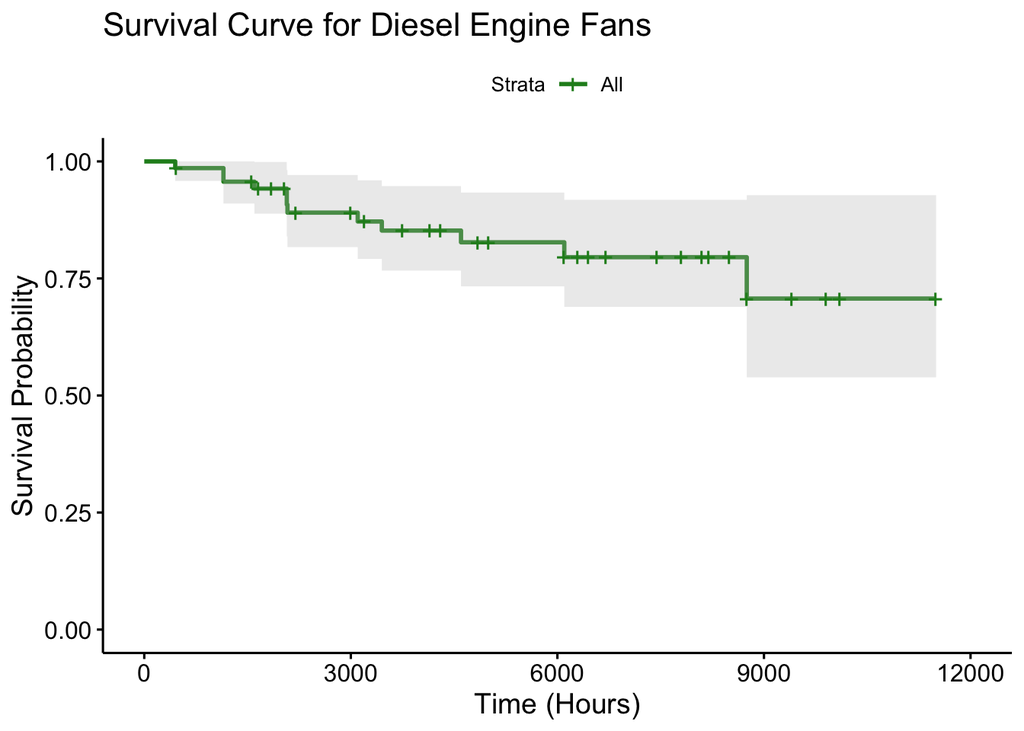

```r
ggsurvplot(fit = km.genfan, data = genfan, palette = "forestgreen", risk.table = F, conf.int = T) +
  labs(title = "Survival Curve for Diesel Engine Fans",
       x = "Time (Hours)",
       y = "Survival Probability")
```

## B (15)

Fit an exponential distribution to the data (accounting for censoring). What is the estimate for the rate parameter?

```r
genfan = genfan %>% mutate(left = hours,
                           right = ifelse(status==1, hours, NA))

interval.genfan = genfan %>% dplyr::select(left,right)

exp.fit = fitdistcens(data.frame(interval.genfan),"weibull",fix.arg=list(shape=1))
summary(exp.fit)
```

```
## Fitting of the distribution ' weibull ' By maximum likelihood on censored data
## Parameters
##       estimate Std. Error
## scale 16670.93   2965.821
## Fixed parameters:
##       value
## shape     1
## Loglikelihood:  -137.3182   AIC:  276.6364   BIC:  278.8849
```

```r
#rate of exponential distribution is equal to 1 / scale of weibull distribution:
rate = 1/as.numeric(unlist(exp.fit[1]))
```

*ANSWER:* Estimate for rate parameter is 5.998467e-05

## 3 (15)

Fit the Weibull distribution to the data (accounting for censoring). What are the estimates for the shape and scale parameters?

```r
weibull.fit = fitdistcens(data.frame(interval.genfan), "weibull")
summary(weibull.fit)
```

```
## Fitting of the distribution ' weibull ' By maximum likelihood on censored data
## Parameters
##           estimate   Std. Error
## shape     1.058443 4.940049e-01
## scale 26301.309460 2.638927e+04
## Loglikelihood:  -135.1527   AIC:  274.3054   BIC:  278.8024
## Correlation matrix:
##            shape      scale
## shape  1.0000000 -0.9481311
## scale -0.9481311  1.0000000
```

*ANSWER:* Estimate for shape parameter: 1.058, estimate for scale: 26301.309

## D (15)

Fit the lognormal distribution to the data (accounting for censoring). What are the estimates for the location and sd parameters?

```r
lnorm.fit = fitdistcens(data.frame(interval.genfan), "lnorm")
summary(lnorm.fit)
```

```
## Fitting of the distribution ' lnorm ' By maximum likelihood on censored data
## Parameters
##          estimate Std. Error
## meanlog 10.145528  0.5222387
## sdlog    1.680757  0.3899058
## Loglikelihood:  -134.5497   AIC:  273.0993   BIC:  277.5963
## Correlation matrix:
##           meanlog     sdlog
## meanlog 1.0000000 0.8285435
## sdlog   0.8285435 1.0000000
```

*ANSWER:* location estimate: 10.146, sd estimate: 1.681.

## E (20)

Create side-by-side QQ plots for the 3 fits using cdfcompcens.

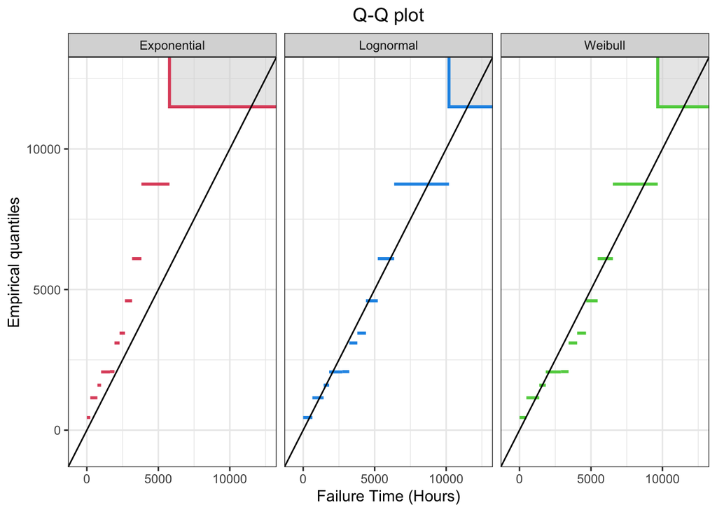

```r
qqcompcens(list(exp.fit,weibull.fit,lnorm.fit),
            legendtext=c("Exponential","Weibull","Lognormal"),
            xlab="Failure Time (Hours)",
            plotstyle = "ggplot")
```

### F (10)

```r
aic = c(exp.fit$aic, weibull.fit$aic, lnorm.fit$aic)
fits = c("exponential", "weibull", "lognormal")

cbind(fits,data.frame(aic))
```

```
##          fits      aic
## 1 exponential 276.6364
## 2     weibull 274.3054
## 3   lognormal 273.0993
```

Which distribution best fits the data? Justify your answer.

*ANSWER:* The lognormal distribution is the best fit because it has the lowest AIC. Also one can see in the QQ plot above that the lognormal data deviates the least from the 45 degree line.

### F

Suppose the stated warranty for the fans is 1000 hours. Using your distribution fit, what’s the probability of a given diesel fan failing in warranty?

```r
plnorm(1000, 10.145528, 1.680757, lower.tail = TRUE)
```

```
## [1] 0.02702862
```

*ANSWER:* The probability of a given diesel fan failing in warranty is .027. There is about a 3% chance that the diesel fan will fail within warranty.